# hw5

HanSun, HanSun97

2020/4/10

1. The complete dataset is too large. Download and import the alcohol sales data for Ames only:

```r
df <- readr::read_csv("2019_Iowa_Liquor_Sales.csv")
head(df)
```

```
## # A tibble: 6 x 24
##   `Invoice/Item N~ Date  `Store Number` `Store Name` Address City
##   <chr>            <chr>          <dbl> <chr>        <chr>   <chr>
## 1 INV-16712000040  01/0~           2500 Hy-Vee Food~ 3800 W~ Ames
## 2 INV-16712000012  01/0~           2500 Hy-Vee Food~ 3800 W~ Ames
## 3 INV-16712000070  01/0~           2500 Hy-Vee Food~ 3800 W~ Ames
## 4 INV-16712000009  01/0~           2500 Hy-Vee Food~ 3800 W~ Ames
## 5 INV-16712000160  01/0~           2500 Hy-Vee Food~ 3800 W~ Ames
## 6 INV-16712000119  01/0~           2500 Hy-Vee Food~ 3800 W~ Ames
## # ... with 18 more variables: `Zip Code` <dbl>, `Store Location` <chr>,
## #   `County Number` <dbl>, County <chr>, Category <dbl>, `Category
## #   Name` <chr>, `Vendor Number` <chr>, `Vendor Name` <chr>, `Item
## #   Number` <dbl>, `Item Description` <chr>, Pack <dbl>, `Bottle Volume
## #   (ml)` <dbl>, `State Bottle Cost` <dbl>, `State Bottle Retail` <dbl>,
## #   `Bottles Sold` <dbl>, `Sale (Dollars)` <dbl>, `Volume Sold
## #   (Liters)` <dbl>, `Volume Sold (Gallons)` <dbl>
```

2.Data cleaning: a. extract geographic latitude and longitude from the variable Store Location

```r
Store_location <- separate(df, "Store Location", into = c("latitude", "longtitude"), sep = " (?=[^ ]+$)")
Store_location$latitude<- gsub("POINT \\(", "", Store_location$latitude)
Store_location$longtitude<- gsub("\\)", "", Store_location$longtitude)
```

2. make sure the variables are in the correct type, by converting incorrect variable types.

```r
Store_location$latitude <- as.numeric(Store_location$latitude)
Store_location$longtitude <- as.numeric(Store_location$longtitude)
Store_location$`Vendor Number` <- as.numeric(Store_location$`Vendor Number`)
Store_location$`Store Name` <- as.factor(Store_location$`Store Name`)
Store_location$`Category Name`<- as.factor(Store_location$`Category Name`)
```

3. extract year, month and day from the variable Date as separate columns.

```r
df_new <- Store_location %>%
  separate(Date, into = c("Month", "Day", "Year"))
head(df_new)
```

```
## # A tibble: 6 x 27
##   `Invoice/Item N~ Month Day   Year  `Store Number` `Store Name` Address
##   <chr>            <chr> <chr> <chr>          <dbl> <fct>        <chr>
## 1 INV-16712000040  01    03    2019            2500 Hy-Vee Food~ 3800 W~
## 2 INV-16712000012  01    03    2019            2500 Hy-Vee Food~ 3800 W~
## 3 INV-16712000070  01    03    2019            2500 Hy-Vee Food~ 3800 W~
## 4 INV-16712000009  01    03    2019            2500 Hy-Vee Food~ 3800 W~
## 5 INV-16712000160  01    03    2019            2500 Hy-Vee Food~ 3800 W~
## 6 INV-16712000119  01    03    2019            2500 Hy-Vee Food~ 3800 W~
## # ... with 20 more variables: City <chr>, `Zip Code` <dbl>,
## #   latitude <dbl>, longtitude <dbl>, `County Number` <dbl>, County <chr>,
## #   Category <dbl>, `Category Name` <fct>, `Vendor Number` <dbl>, `Vendor
## #   Name` <chr>, `Item Number` <dbl>, `Item Description` <chr>,
## #   Pack <dbl>, `Bottle Volume (ml)` <dbl>, `State Bottle Cost` <dbl>,
## #   `State Bottle Retail` <dbl>, `Bottles Sold` <dbl>, `Sale
## #   (Dollars)` <dbl>, `Volume Sold (Liters)` <dbl>, `Volume Sold
## #   (Gallons)` <dbl>
```

3. First overview:
1. Plot a scatterplot of lat and long of store locations.

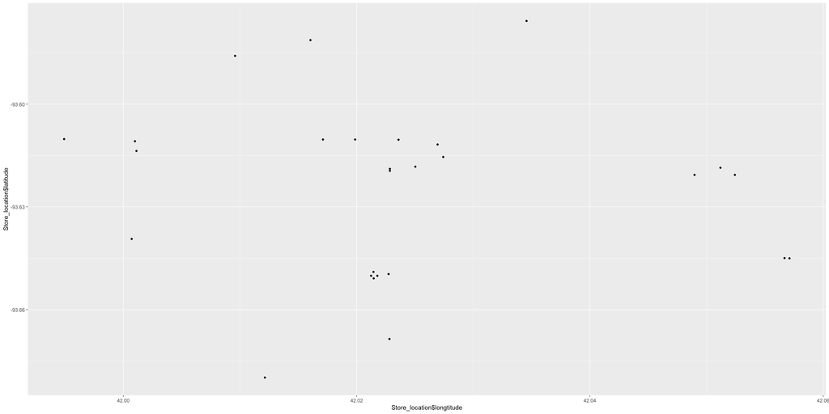

```r
ggplot(df_new, aes(x=Store_location$longtitude, y=Store_location$latitude)) + geom_point()
```

2. Provide a visual breakdown of the liquor category (by Category Name). Include volume sold in the breakdown.

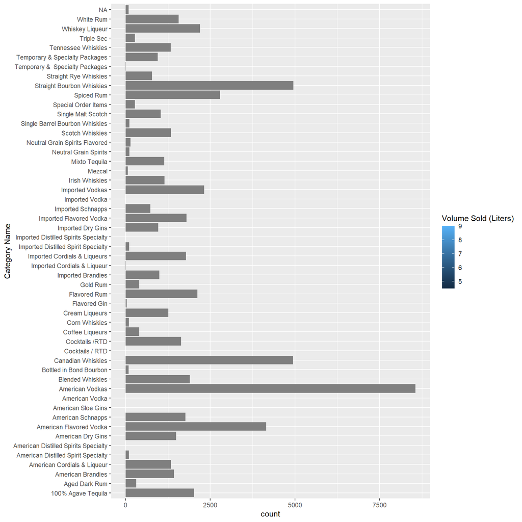

```r
df_new %>%
  group_by(`Category Name`) %>%
  ggplot(aes(x = `Category Name`, fill = `Volume Sold (Liters)`)) + geom_bar() + coord_flip()
```

4. Find the daily sales liquor sales in Ames in 2019. Summarize the number of sales, volume of liquor sold, and amount of money spent.

```r
df_2019 <- df_new %>%
  filter(Year == 2019)
df_sales <- df_2019 %>%
  group_by(Day, Month) %>%
  summarize(Sales = sum(`Bottles Sold`), Vol = sum(`Volume Sold (Gallons)`), amount = sum(`Sale (Dollars)`))
df_sales
```

```
## # A tibble: 157 x 5
## # Groups:   Day [31]
##    Day   Month Sales     Vol   amount
##    <chr> <chr> <dbl>   <dbl>    <dbl>
##  1 01    02     1225  333.    19438.
##  2 01    03     1655  410.    22531.
##  3 01    05     1715  558.    31963.
##  4 01    08     3347  717.    44361.
##  5 01    10      255   49.0    3526.
##  6 01    11      623  172.     6512.
##  7 02    05     9468 2261.   132643.
##  8 02    07        1    0.26     18.8
##  9 02    08      431   65.6    4046.
## 10 02    10     4912 1131.    65284.
## # ... with 147 more rows
```

5. Plot volume sold by day (use a scatterplot of volume by day and facet by month). Discover any trend with the help of geom_smooth. Describe any patterns.

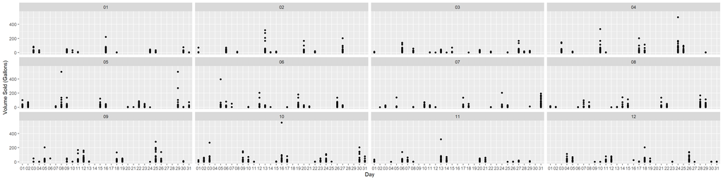

```r
ggplot(df_2019, aes(x = Day, y = `Volume Sold (Gallons)`)) + geom_point() + facet_wrap(~Month)
```

6. Find the dates for ISU football home games in Fall 2019. Can you see a pattern?

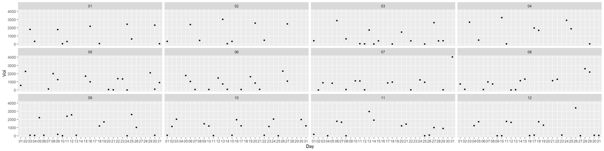

```r
df_sales %>% ggplot(aes(x = Day, y = Vol)) + geom_point() + facet_wrap(~Month)
```